# Reading in a NetCDF file in R

kate Brown

20/6/2021

# Energy-climate data hackathon

## Using R (version 3.6.3) with ERA5 data

This notebook shows you how to work with the ERA5 data available on Jasmin using R. It demonstrates:

- how to open and read in a netcdf file,
- how to read in just a part of a netcdf file,
- how to plot a time series for an individual point
- how to calculate a daily mean,
- how to create a simple and more advanced plots

This code requires the following:

- a Netcdf file of ERA5 temperature data

Within R they are many ways of producing similar plots or analysis. The examples shown below illustrate one approach. I make no claim that this is the best or most efficient approach. However, I’m always interested in learning new or different approaches to writing code in R. If you have some comments or code that you would like to share, I can be contacted at kate.brown@metoffice.gov.uk. I hope you enjoy the Hackathon.

Kate Brown 18/6/2021

## Preparatory actions

Load in relevant R libraries

```r
library(ncdf4)
library(raster)
## Loading required package: sp
##
## Attaching package: 'raster'
## The following object is masked from 'package:nlme':
##
##     getData
library(viridis)
## Loading required package: viridisLite
library(maps)
##
## Attaching package: 'maps'
## The following object is masked from 'package:viridis':
##
##     unemp
library(maptools)
## Checking rgeos availability: TRUE
library(proj4)
library(tictoc)
```

Specify directories and files

```r
dir_in <- '** directory path ***'
file_in <- 'ERA5_1hr_1979_01_DET.nc'

path_file <- file.path(dir_in, file_in, fsep = "/")
```

## Open a netCDF data file for reading and print out information about the file and its contents.

```r
ncin <- nc_open(path_file)

print(ncin)
```

```
##
##      6 variables (excluding dimension variables):
##         short u10[longitude,latitude,time]
##             scale_factor: 0.000802634471179477
##             add_offset: -1.35310059702075
##             _FillValue: -32767
##             missing_value: -32767
##             units: m s**-1
##             long_name: 10 metre U wind component
##         short v10[longitude,latitude,time]
##             scale_factor: 0.000824914356871013
##             add_offset: -1.83583115835031
##             _FillValue: -32767
##             missing_value: -32767
##             units: m s**-1
##             long_name: 10 metre V wind component
##         short u100[longitude,latitude,time]
##             scale_factor: 0.00102759735515826
##             add_offset: -1.77174640365805
##             _FillValue: -32767
##             missing_value: -32767
##             units: m s**-1
##             long_name: 100 metre U wind component
##         short v100[longitude,latitude,time]
##             scale_factor: 0.00105617303682222
##             add_offset: -1.80017255673325
##             _FillValue: -32767
##             missing_value: -32767
##             units: m s**-1
##             long_name: 100 metre V wind component
##         short t2m[longitude,latitude,time]
##             scale_factor: 0.00134094679748359
##             add_offset: 262.03360839623
##             _FillValue: -32767
##             missing_value: -32767
##             units: K
##             long_name: 2 metre temperature
##         short msl[longitude,latitude,time]
##             scale_factor: 0.136230982863595
##             add_offset: 100836.369384509
##             _FillValue: -32767
##             missing_value: -32767
##             units: Pa
##             long_name: Mean sea level pressure
##             standard_name: air_pressure_at_mean_sea_level
##
##      3 dimensions:
##         longitude  Size:304
##             units: degrees_east
##             long_name: longitude
##         latitude  Size:214
##             units: degrees_north
##             long_name: latitude
##         time  Size:744
##             units: hours since 1900-01-01 00:00:00.0
##             long_name: time
##             calendar: gregorian
##
##     2 global attributes:
##         Conventions: CF-1.6
##         history: 2020-07-24 08:23:53 GMT by grib_to_netcdf-2.16.0: /opt/ecmwf/eccodes/bin/grib_to_netcdf -S param -o /cache/data8/adaptor.mars.internal-1595578799.3522663-21900-32-92ac8c79-dbc6-4329-90b2-f4176d0bbc96.nc /cache/tmp/92ac8c79-dbc6-4329-90b2-f4176d0bbc96-adaptor.mars.internal-1595578…
```

Print the list of objects that the netcdf file contains

```r
var_names <- unlist(attributes(ncin$var))

print(unname(var_names))  # uname removes the name attributes in R, so just the names of the objects are printed
```

```
## [1] "u10"  "v10"  "u100" "v100" "t2m"  "msl"
```

Read all the temperature data in from the netCDF file. The commands tic() and toc() time this process. You could use Sys.time() instead.

```r
tic("Time taken to read in all the data")

temp_data <- ncvar_get(ncin, varid = "t2m") - 273.15

toc()
```

```
## Time taken to read in all the data: 6.471 sec elapsed
```

## Read in just the data around the uk.

Subsetting the data to a smaller area results in the data being read in quicker.

```r
tic("Time taken to read in just the data around the UK")
LonIdx <- which(ncin$dim$lon$vals > -12 & ncin$dim$lon$vals < 4)
LatIdx <- which(ncin$dim$lat$vals > 49 & ncin$dim$lat$vals < 61)


uk_data <- ncvar_get(ncin, varid = "t2m", start = c(LonIdx[1] ,LatIdx[1], 1),
                     count = c(length(LonIdx),length(LatIdx),ncin$dim$time$len))
toc()

test_data <- temp_data
print("Dimension of the temperature array")
dim(temp_data)

cat("\n First 10 observations in temp_data \n")
head(temp_data)
## Time taken to read in just the data around the UK: 0.162 sec elapsed
## [1] "Dimension of the temperature array"
## [1] 304 214 744
##
##  First 10 observations in temp_data
## [1] -28.88662 -28.88662 -28.88930 -28.88930 -28.89064 -28.89064
```

## An approach to calculating the daily mean

Check what type of calendar the data uses

```r
cat("Type of calendar:",ncin$dim$time$calendar)

cat('\nTime is measured as', ncin$dim$time$units)
```

```
## Type of calendar: gregorian
## Time is measured as hours since 1900-01-01 00:00:00.0
```

Create R datetime variable

```r
era5_datetime <- as.POSIXct(ncin$dim$time$vals*60*60, origin = "1900-01-01 00:00:00")
```

Print out the first 6 and last 6 times

```r
head(era5_datetime)
tail(era5_datetime)
```

```
## [1] "1979-01-01 00:00:00 GMT" "1979-01-01 01:00:00 GMT"
## [3] "1979-01-01 02:00:00 GMT" "1979-01-01 03:00:00 GMT"
## [5] "1979-01-01 04:00:00 GMT" "1979-01-01 05:00:00 GMT"
## [1] "1979-01-31 18:00:00 GMT" "1979-01-31 19:00:00 GMT"
## [3] "1979-01-31 20:00:00 GMT" "1979-01-31 21:00:00 GMT"
## [5] "1979-01-31 22:00:00 GMT" "1979-01-31 23:00:00 GMT"
```

Calculate the daily means

```r
day <- format(era5_datetime, "%d/%m/%Y")


# temp_data has 304 longitude, 214 latitudes and 744 hourly observations.

dim(temp_data) <- c(dim(temp_data)[1:2],24,31)

day_mean <- apply(X = temp_data, c(1, 2, 4), FUN = mean)
```

## Simple timeseries plot

Produce a plot for a single point with the timeseries of the hourly temperature mean and overlay the daily means

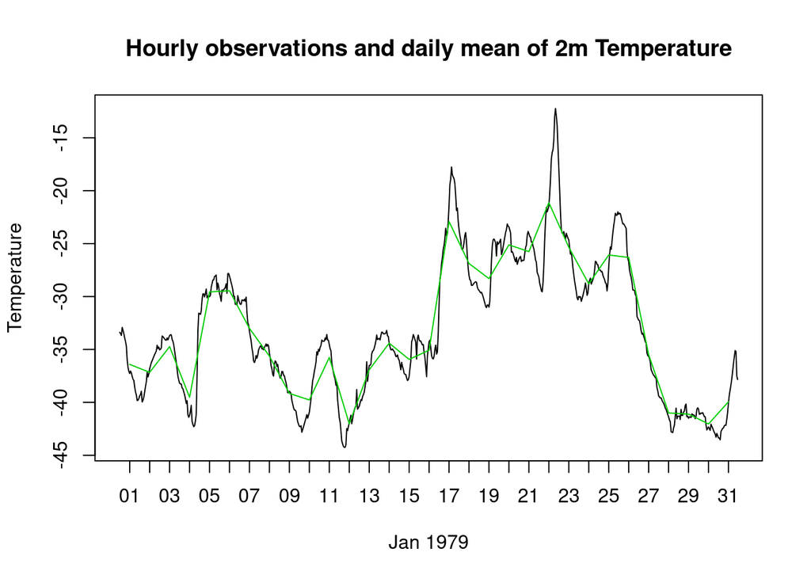

```r
lon <- 56
lat <- 45

plot(era5_datetime,
     temp_data[lon, lat, ,],
     col = 1,
     type = "l",
     xlab = format(era5_datetime[1], "%b %Y"),
     ylab = "Temperature",
     xaxt = "n",
     main = "Hourly observations and daily mean of 2m Temperature")

axis(1, at = era5_datetime[seq(from = 13, to = 744, by = 24)],
     labels = format(era5_datetime[seq(from = 13,to = 744, by = 24)], "%d"))

era5_day <- era5_datetime[seq(from = 13, to = 744, by = 24)]
lines(era5_day, day_mean[lon, lat, ], col = 3)
```

## Plotting maps of the data

Make a simple spatial plot of the first hour in the data. (There are probably many different ways in R that this can be done. The method shown below uses rasters, I expect these plots could also be produced using ggplot or other graphical libraries in R)

Read netCDF file into R as a raster brick - a multi-layer raster object. Here the layers are the hours. Plot the first hour.

```r
temp1 <- brick(path_file, varname = "t2m") - 273.15
```

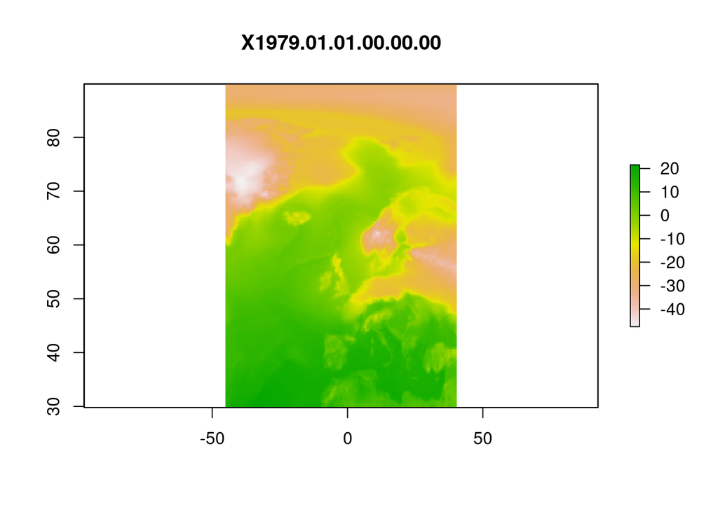

```r
plot(temp1,1)
```

Change the colour scheme, I like viridis. It is meant to be good for most forms of colour blindness and good for printing out in black and white.

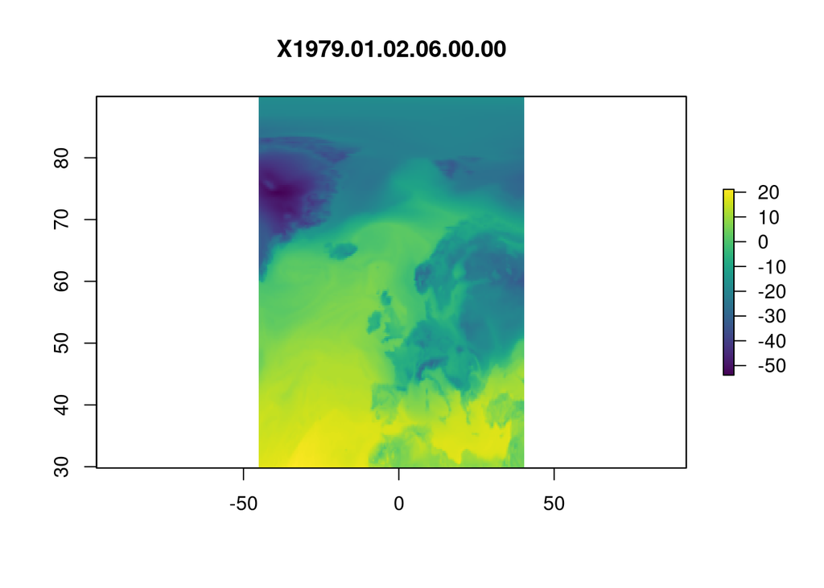

```r
plot(temp1, 31, col = viridis(256))
```

Narrow the output to just UK and Ireland, and add a coastline.

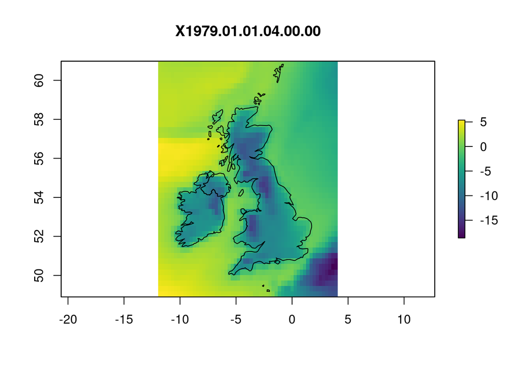

```r
uk_coast <- map("world",
                c("UK", "Ireland", "Jersey", "Guernsey", "Isle of Man"),
                xlim = c(-12, 4),
                ylim = c(49, 61),
                fill = T,
                col = "transparent",
                plot = F)

ids <- sapply(strsplit(uk_coast$names, ":"), function(x) x[1])

# convert the coastlines a spatial polygon

uk_cst_sp <- map2SpatialPolygons(uk_coast, IDs = ids, proj4string =
                                     CRS("+proj=longlat +datum=WGS84"))
# Transform the spatial polygon from standard lat/lon projection to
# the projection used for the land sea mask.

# crop to he UK and Ireland

temp_sp <- as(extent(-12, 4, 49, 61), 'SpatialPolygons')
crs(temp_sp) <- "+proj=longlat +datum=WGS84 +no_defs"
temp_uk <- crop(temp1,temp_sp)
# plot the temperatures for the 5th hour and then add the coast outline

plot(temp_uk, 5, col = viridis(256))

plot(uk_cst_sp, add = T)
```

Select a different part of Europe: Iberian Peninsula

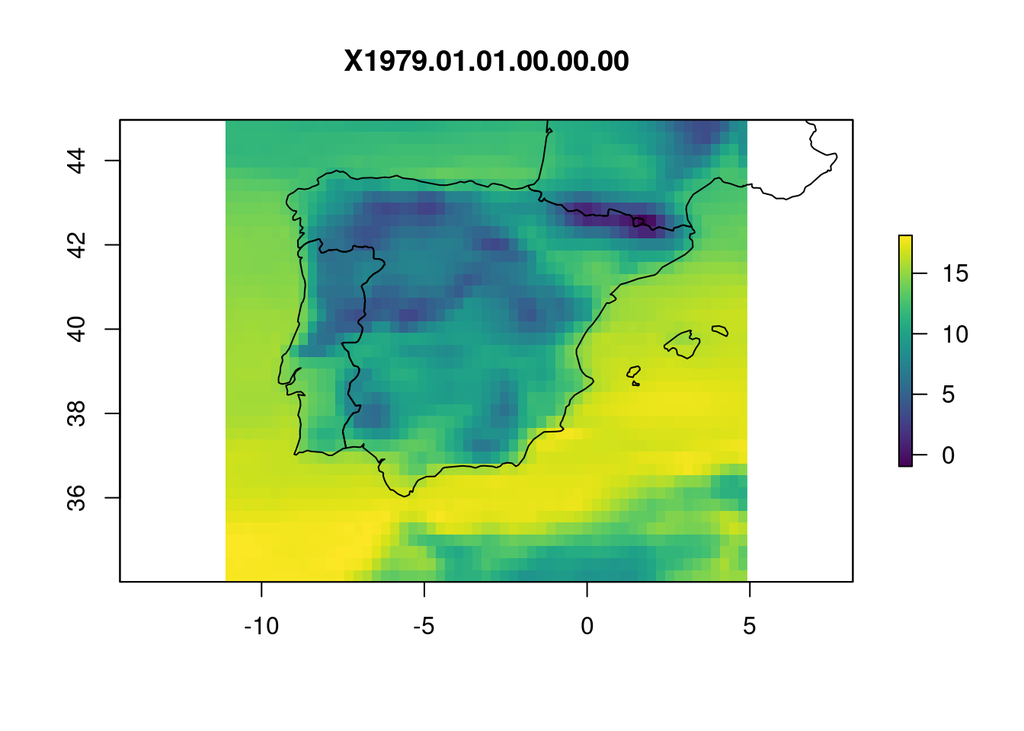

```r
# Select out parts of the world map that we want


Iberian_coast <- map("world",
                c("Spain","Portugal","Andorra","France"),
                xlim = c(-11, 5),
                ylim = c(34, 45),
                fill = T,
                col = "transparent",
                plot = F)

ids <- sapply(strsplit(Iberian_coast$names, ":"), function(x) x[1])

# convert the coastlines a spatial polygon

Ib_cst_sp <- map2SpatialPolygons(Iberian_coast, IDs = ids, proj4string =
                                     CRS("+proj=longlat +datum=WGS84"))
# Transform the spatial polygon from standard lat/lon projection to
# the projection used for the land sea mask.



temp_sp <- as(extent(-11, 5, 34, 45), 'SpatialPolygons')
crs(temp_sp) <- "+proj=longlat +datum=WGS84 +no_defs"
temp_spain <- crop(temp1,temp_sp)
plot(temp_spain,1, col = viridis(256))
plot(Ib_cst_sp, add = T)
```